# Park Access Analysis

Cathy Liu

2022-06-17

#### The main goal of the research is to identify the green space availability in U.S. cities; it measures how well cities meet their resident’s need for parks based on four metrics: park access, acreage, investment, and amenities. Data Analytics play an important role in finding out different trends such as cities with lowest/highest Spending per resident in USD before and after covid-19.

```r
library(tidyverse)
library(randomForest)
```

```r
library(skimr)
library(ggplot2)
library(widyr)
```

### Import dataset and count parks in cities

```r
parks <- readr::read_csv('https://raw.githubusercontent.com/rfordatascience/tidytuesday/master/data/2021/2021-06-22/parks.csv')
parks
```

```
## # A tibble: 713 × 28
##     year  rank city           med_park_size_d… med_park_size_p… park_pct_city_d…
##    <dbl> <dbl> <chr>                     <dbl>            <dbl> <chr>
##  1  2020     1 Minneapolis                 5.7               26 15%
##  2  2020     2 Washington, D…              1.4                5 24%
##  3  2020     3 St. Paul                    3.2               14 15%
##  4  2020     4 Arlington, Vi…              2.4               10 11%
##  5  2020     5 Cincinnati                  4.4               20 14%
##  6  2020     6 Portland                    4.9               22 18%
##  7  2020     7 Irvine                      6.1               28 27%
##  8  2020     8 San Francisco               1.3                4 21%
##  9  2020     9 Boston                      1.4                4 17%
## 10  2020    10 Chicago                     2.2                9 10%
## # … with 703 more rows, and 22 more variables: park_pct_city_points <dbl>,
## #   pct_near_park_data <chr>, pct_near_park_points <dbl>,
## #   spend_per_resident_data <chr>, spend_per_resident_points <dbl>,
## #   basketball_data <dbl>, basketball_points <dbl>, dogpark_data <dbl>,
## #   dogpark_points <dbl>, playground_data <dbl>, playground_points <dbl>,
## #   rec_sr_data <dbl>, rec_sr_points <dbl>, restroom_data <dbl>,
## #   restroom_points <dbl>, splashground_data <dbl>, …
```

```r
parks %>% count(city)
```

```
## # A tibble: 102 × 2
##    city                    n
##    <chr>               <int>
##  1 Albuquerque             9
##  2 Anaheim                 7
##  3 Anchorage               6
##  4 Arlington, Texas        8
##  5 Arlington, Virginia     5
##  6 Atlanta                 9
##  7 Aurora                  7
##  8 Austin                  9
##  9 Bakersfield             7
## 10 Baltimore               9
## # … with 92 more rows
```

### Data Waggling. Using parse_number() to convert percents and dollars to numbers, convert remaining character data columns to factors,remove duplicate column

```r
parks_df <- parks %>%
  mutate(park_pct_city_data = parse_number(park_pct_city_data),
         pct_near_park_data = parse_number(pct_near_park_data),
         spend_per_resident_data = parse_number(spend_per_resident_data)) %>%
  mutate(across(where(is.character), factor)) %>%
  select(-city_dup)
parks_df
```

```
## # A tibble: 713 × 27
##     year  rank city           med_park_size_d… med_park_size_p… park_pct_city_d…
##    <dbl> <dbl> <fct>                     <dbl>            <dbl>            <dbl>
##  1  2020     1 Minneapolis                 5.7               26               15
##  2  2020     2 Washington, D…              1.4                5               24
##  3  2020     3 St. Paul                    3.2               14               15
##  4  2020     4 Arlington, Vi…              2.4               10               11
##  5  2020     5 Cincinnati                  4.4               20               14
##  6  2020     6 Portland                    4.9               22               18
##  7  2020     7 Irvine                      6.1               28               27
##  8  2020     8 San Francisco               1.3                4               21
##  9  2020     9 Boston                      1.4                4               17
## 10  2020    10 Chicago                     2.2                9               10
## # … with 703 more rows, and 21 more variables: park_pct_city_points <dbl>,
## #   pct_near_park_data <dbl>, pct_near_park_points <dbl>,
## #   spend_per_resident_data <dbl>, spend_per_resident_points <dbl>,
## #   basketball_data <dbl>, basketball_points <dbl>, dogpark_data <dbl>,
## #   dogpark_points <dbl>, playground_data <dbl>, playground_points <dbl>,
## #   rec_sr_data <dbl>, rec_sr_points <dbl>, restroom_data <dbl>,
## #   restroom_points <dbl>, splashground_data <dbl>, …
```

### Display the summary of cities that have less than 20 in total points

```r
summ <- parks_df %>%
filter(total_points < 20)%>%
select(year,city,total_points)
summ
```

```
## # A tibble: 75 × 3
##     year city             total_points
##    <dbl> <fct>                   <dbl>
##  1  2015 Minneapolis                14
##  2  2015 St. Paul                   18
##  3  2015 Washington, D.C.           16
##  4  2015 San Francisco              10
##  5  2015 New York                   10
##  6  2015 Portland                   13
##  7  2015 Cincinnati                 19
##  8  2015 Boston                     13
##  9  2015 San Diego                  11
## 10  2015 Seattle                    11
## # … with 65 more rows
```

```r
summary(summ)
```

```
##       year                    city     total_points
##  Min.   :2015   Albuquerque     : 1   Min.   : 3.00
##  1st Qu.:2015   Anaheim         : 1   1st Qu.: 7.00
##  Median :2015   Anchorage       : 1   Median :11.00
##  Mean   :2015   Arlington, Texas: 1   Mean   : 9.92
##  3rd Qu.:2015   Atlanta         : 1   3rd Qu.:12.00
##  Max.   :2015   Aurora          : 1   Max.   :19.00
##                 (Other)         :69
```

```r
green <- parks_df %>%
  mutate(Green_City = case_when(med_park_size_points > 20 ~ med_park_size_points))
green
```

```
## # A tibble: 713 × 28
##     year  rank city           med_park_size_d… med_park_size_p… park_pct_city_d…
##    <dbl> <dbl> <fct>                     <dbl>            <dbl>            <dbl>
##  1  2020     1 Minneapolis                 5.7               26               15
##  2  2020     2 Washington, D…              1.4                5               24
##  3  2020     3 St. Paul                    3.2               14               15
##  4  2020     4 Arlington, Vi…              2.4               10               11
##  5  2020     5 Cincinnati                  4.4               20               14
##  6  2020     6 Portland                    4.9               22               18
##  7  2020     7 Irvine                      6.1               28               27
##  8  2020     8 San Francisco               1.3                4               21
##  9  2020     9 Boston                      1.4                4               17
## 10  2020    10 Chicago                     2.2                9               10
## # … with 703 more rows, and 22 more variables: park_pct_city_points <dbl>,
## #   pct_near_park_data <dbl>, pct_near_park_points <dbl>,
## #   spend_per_resident_data <dbl>, spend_per_resident_points <dbl>,
## #   basketball_data <dbl>, basketball_points <dbl>, dogpark_data <dbl>,
## #   dogpark_points <dbl>, playground_data <dbl>, playground_points <dbl>,
## #   rec_sr_data <dbl>, rec_sr_points <dbl>, restroom_data <dbl>,
## #   restroom_points <dbl>, splashground_data <dbl>, …
```

```r
green_num<-green %>%
  group_by(year) %>%
  filter(!is.na(Green_City)) %>%
  count(Green_City)
count(green_num)
```

```
## # A tibble: 2 × 2
## # Groups:   year [2]
##    year     n
##   <dbl> <int>
## 1  2019    12
## 2  2020    23
```

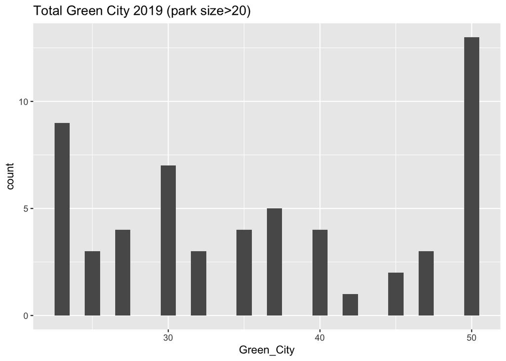

```r
green %>%
  filter(year=="2019") %>%
ggplot(
  aes(x=Green_City)
)+
  geom_histogram(binwidth=1)+
  labs(title="Total Green City 2019 (park size>20)")
```

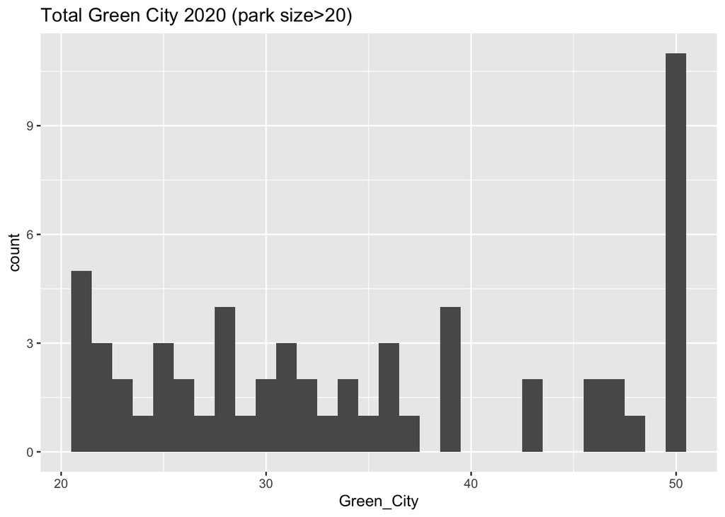

```r
green %>%
  filter(year=="2020") %>%
ggplot(
  aes(x=Green_City)
)+
  geom_histogram(binwidth=1)+
  labs(title="Total Green City 2020 (park size>20)")
```

### Create a group of cities with highest Spending per resident in USD before and after covid-19

```r
max_before_covid <- parks_df%>%
filter(year < 2019)%>%
group_by(city) %>%
  summarise(highest_Spending_beforeCovid = max(spend_per_resident_data))
max_before_covid
```

```
## # A tibble: 100 × 2
##    city                highest_Spending_beforeCovid
##    <fct>                                      <dbl>
##  1 Albuquerque                                   68
##  2 Anaheim                                       73
##  3 Anchorage                                     98
##  4 Arlington, Texas                              90
##  5 Arlington, Virginia                          240
##  6 Atlanta                                      139
##  7 Aurora                                       143
##  8 Austin                                       108
##  9 Bakersfield                                   96
## 10 Baltimore                                     78
## # … with 90 more rows
```

```r
ave_before<-mean(max_before_covid$highest_Spending_beforeCovid)
median_before<-median(max_before_covid$highest_Spending_beforeCovid)
max_after_covid <- parks_df%>%
filter(year >= 2019)%>%
group_by(city) %>%
  summarise(highest_Spending_afterCovid = max(spend_per_resident_data))
max_after_covid
```

```
## # A tibble: 97 × 2
##    city                highest_Spending_afterCovid
##    <fct>                                     <dbl>
##  1 Albuquerque                                  65
##  2 Anaheim                                     115
##  3 Anchorage                                    99
##  4 Arlington, Texas                            102
##  5 Arlington, Virginia                         301
##  6 Atlanta                                     151
##  7 Aurora                                      149
##  8 Austin                                      147
##  9 Bakersfield                                  86
## 10 Baltimore                                    73
## # … with 87 more rows
```

```r
ave_after<-mean(max_after_covid$highest_Spending_afterCovid)
median_after<-median(max_after_covid$highest_Spending_afterCovid)
parks_df %>% select(year,city,spend_per_resident_data) %>%
  filter(city=="Washington, DC" |
         city=="Washington, D.C."
         )
```

```
## # A tibble: 9 × 3
##    year city             spend_per_resident_data
##   <dbl> <fct>                              <dbl>
## 1  2020 Washington, D.C.                    307
## 2  2019 Washington, D.C.                    270
## 3  2018 Washington, D.C.                    257
## 4  2017 Washington, D.C.                    270
## 5  2016 Washington, D.C.                    287
## 6  2015 Washington, D.C.                    343
## 7  2014 Washington, DC                      353
## 8  2013 Washington, DC                      344.
## 9  2012 Washington, DC                      303.
```

```r
CovB<- max_before_covid %>%
top_n(10, highest_Spending_beforeCovid)
CovB
```

```
## # A tibble: 10 × 2
##    city                highest_Spending_beforeCovid
##    <fct>                                      <dbl>
##  1 Arlington, Virginia                         240
##  2 Irvine                                      255
##  3 Las Vegas                                   230
##  4 Minneapolis                                 249
##  5 Portland                                    251
##  6 San Francisco                               292.
##  7 Seattle                                     279
##  8 St. Louis                                   271
##  9 Washington, D.C.                            343
## 10 Washington, DC                              353
```

```r
CovA<- max_after_covid %>%
top_n(10, highest_Spending_afterCovid)
CovA
```

```
## # A tibble: 10 × 2
##    city                highest_Spending_afterCovid
##    <fct>                                     <dbl>
##  1 Arlington, Virginia                         301
##  2 Irvine                                      252
##  3 Minneapolis                                 319
##  4 New York                                    232
##  5 Plano                                       226
##  6 Portland                                    250
##  7 San Francisco                               399
##  8 Seattle                                     320
##  9 St. Louis                                   261
## 10 Washington, D.C.                            307
```

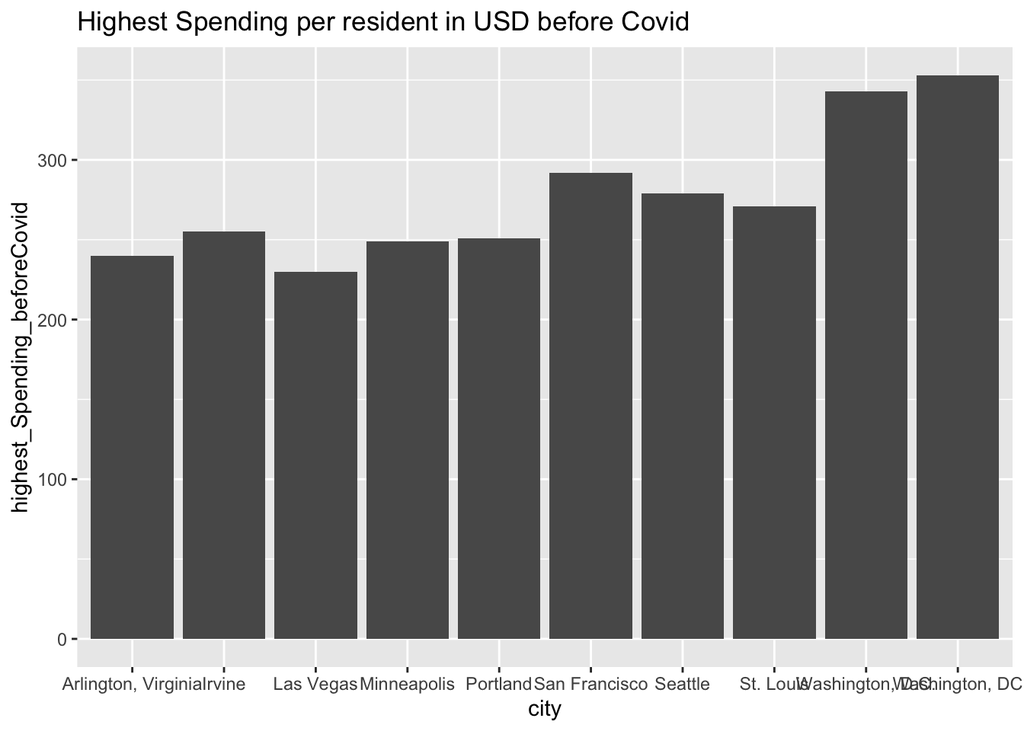

```r
(ggplot(CovB)+
  geom_bar(aes(x=city, y=highest_Spending_beforeCovid),
            stat = "identity")+
  labs(title='Highest Spending per resident in USD before Covid'))
```

```
## No summary function supplied, defaulting to `mean_se()`
```

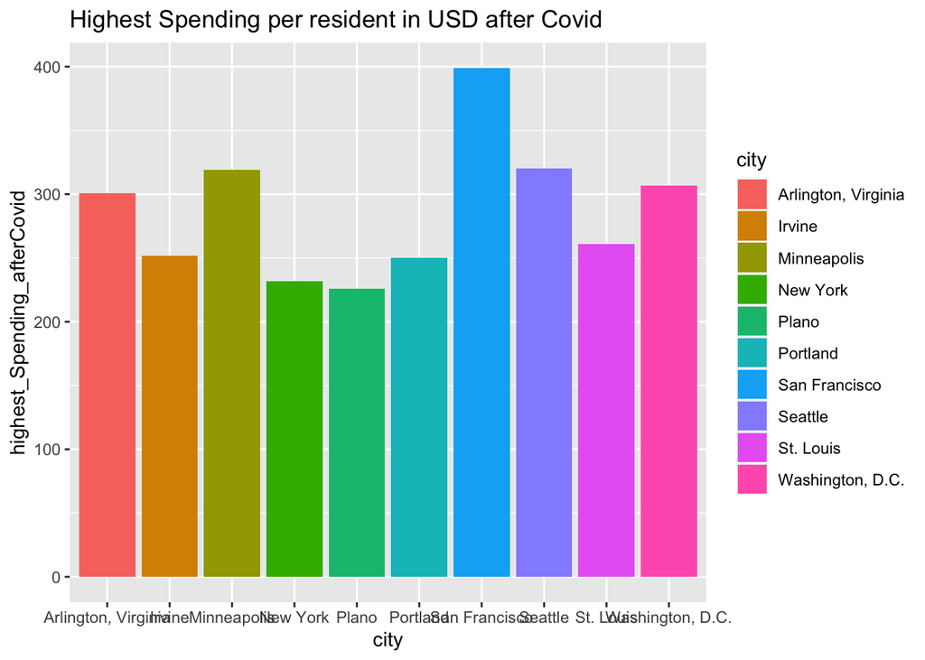

```r
(ggplot(CovA)+
  geom_bar(aes(x=city, y=highest_Spending_afterCovid,fill=city),
            stat = "summary")+
  labs(title='Highest Spending per resident in USD after Covid'))
```

### Create a group of cities with lowest Spending per resident in USD before and after covid-19.

```r
min_before_covid <- parks_df%>%
filter(year < 2019)%>%
group_by(city) %>%
  summarise(Lowest_Spending_beforeCovid = min(spend_per_resident_data))
min_before_covid
```

```
## # A tibble: 100 × 2
##    city                Lowest_Spending_beforeCovid
##    <fct>                                     <dbl>
##  1 Albuquerque                                58
##  2 Anaheim                                    65
##  3 Anchorage                                  74
##  4 Arlington, Texas                           76.3
##  5 Arlington, Virginia                       230
##  6 Atlanta                                    87
##  7 Aurora                                    125
##  8 Austin                                     66.3
##  9 Bakersfield                                74
## 10 Baltimore                                  61.2
## # … with 90 more rows
```

```r
ave_min_before<-mean(min_before_covid $Lowest_Spending_beforeCovid)
median_min_before<-median(min_before_covid $Lowest_Spending_beforeCovid)
min_after_covid <- parks_df%>%
filter(year >= 2019)%>%
group_by(city) %>%
  summarise(Lowest_Spending_afterCovid = min(spend_per_resident_data))
min_after_covid
```

```
## # A tibble: 97 × 2
##    city                Lowest_Spending_afterCovid
##    <fct>                                    <dbl>
##  1 Albuquerque                                 62
##  2 Anaheim                                     99
##  3 Anchorage                                   93
##  4 Arlington, Texas                            92
##  5 Arlington, Virginia                        267
##  6 Atlanta                                    138
##  7 Aurora                                     145
##  8 Austin                                     119
##  9 Bakersfield                                 81
## 10 Baltimore                                   69
## # … with 87 more rows
```

```r
ave_min_after<-mean(min_after_covid$Lowest_Spending_afterCovid)
median_min_after<-median(min_after_covid$Lowest_Spending_afterCovid)
CovvB<- min_before_covid %>%
top_n(10, Lowest_Spending_beforeCovid)
CovvB
```

```
## # A tibble: 10 × 2
##    city                Lowest_Spending_beforeCovid
##    <fct>                                     <dbl>
##  1 Arlington, Virginia                        230
##  2 Cincinnati                                 181
##  3 Irvine                                     227
##  4 Minneapolis                                210.
##  5 New York                                   152.
##  6 San Francisco                              216
##  7 Seattle                                    257
##  8 St. Paul                                   202
##  9 Washington, D.C.                           257
## 10 Washington, DC                             303.
```

```r
CovvB %>% summarise(
    average_CovvB=mean(Lowest_Spending_beforeCovid, na.rm=TRUE)
)
```

```
## # A tibble: 1 × 1
##   average_CovvB
##           <dbl>
## 1          224.
```

```r
CovvA<- min_after_covid %>%
top_n(10, Lowest_Spending_afterCovid)
CovvA
```

```
## # A tibble: 10 × 2
##    city                Lowest_Spending_afterCovid
##    <fct>                                    <dbl>
##  1 Arlington, Virginia                        267
##  2 Irvine                                     215
##  3 Minneapolis                                299
##  4 Plano                                      211
##  5 Portland                                   224
##  6 San Francisco                              318
##  7 Seattle                                    279
##  8 St. Louis                                  199
##  9 St. Paul                                   219
## 10 Washington, D.C.                           270
```

```r
CovvA %>% summarise(
    average_Covva=mean(Lowest_Spending_afterCovid, na.rm=TRUE)
)
```

```
## # A tibble: 1 × 1
##   average_Covva
##           <dbl>
## 1          250.
```

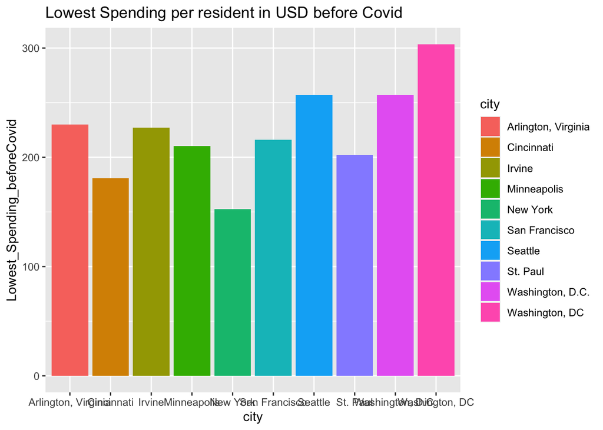

```r
(ggplot(CovvB)+
  geom_bar(aes(x=city, y=Lowest_Spending_beforeCovid,fill=city),
            stat = "identity")+
  labs(title='Lowest Spending per resident in USD before Covid'))
```

```
## No summary function supplied, defaulting to `mean_se()`
```

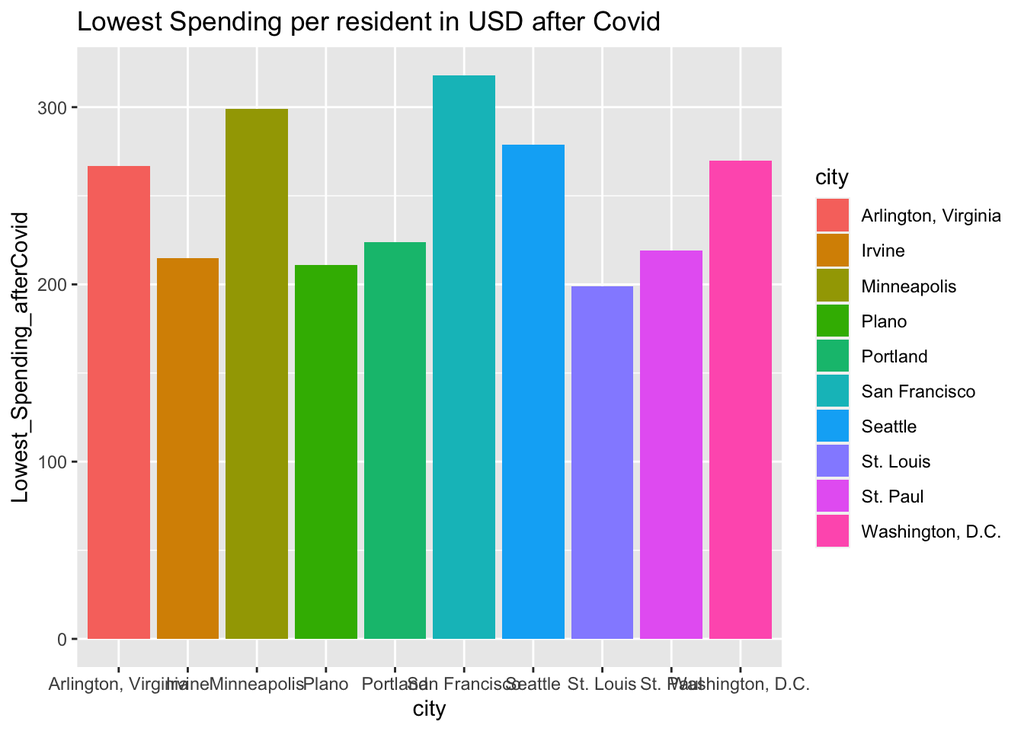

```r
(ggplot(CovvA)+
  geom_bar(aes(x=city, y=Lowest_Spending_afterCovid,fill=city),
            stat = "summary")+
  labs(title='Lowest Spending per resident in USD after Covid'))
```

```r
parks_df %>% select(year,city,spend_per_resident_data) %>%
  filter(city=="Plano"
         )
```

```
## # A tibble: 6 × 3
##    year city  spend_per_resident_data
##   <dbl> <fct>                   <dbl>
## 1  2020 Plano                     226
## 2  2019 Plano                     211
## 3  2018 Plano                     197
## 4  2017 Plano                     147
## 5  2016 Plano                     125
## 6  2015 Plano                     125
```

#### The average max per resident investment before COVID-19 is $116.6075, and the median is $99. While the average per resident investment after COVID-19 is $117.46, and the median is $94.

```r
news<- parks_df %>%
arrange(desc(rank))
data <- news[1:10,]
print(knitr::kable(data, "pipe"))
```

```
##
##
## | year| rank|city          | med_park_size_data| med_park_size_points| park_pct_city_data| park_pct_city_points| pct_near_park_data| pct_near_park_points| spend_per_resident_data| spend_per_resident_points| basketball_data| basketball_points| dogpark_data| dogpark_points| playground_data| playgro…
## |----:|----:|:-------------|------------------:|--------------------:|------------------:|--------------------:|------------------:|--------------------:|-----------------------:|-------------------------:|---------------:|-----------------:|------------:|--------------:|---------------:|--------…
## | 2017|   98|Fort Wayne    |                4.0|                  7.0|                  3|                  3.0|                 44|                   10|                      79|                       8.0|             1.8|               5.0|          0.8|              7|             2.3|        …
## | 2017|   98|Indianapolis  |                9.8|                 19.0|                  5|                  5.0|                 32|                    3|                      35|                       2.0|             2.2|               7.0|          0.5|              3|             1.5|        …
## | 2016|   98|Fort Wayne    |                3.9|                  7.0|                  3|                  3.0|                 42|                    9|                      70|                       8.0|             1.7|               5.0|          0.8|              8|             2.2|        …
## | 2020|   97|Oklahoma City |                5.0|                 22.0|                  5|                 10.0|                 38|                    5|                      57|                      26.0|             1.7|              14.0|          0.3|              1|             1.6|        …
## | 2019|   97|Oklahoma City |                5.0|                 22.5|                  4|                  7.5|                 38|                   10|                      70|                      32.5|             1.9|              20.0|          0.4|              5|             2.5|        …
## | 2018|   97|Charlotte     |               18.0|                 20.0|                  4|                  4.0|                 28|                    1|                      47|                       7.0|             1.1|               2.0|          0.6|              8|             1.9|        …
## | 2017|   97|Charlotte     |               16.6|                 20.0|                  4|                  4.0|                 27|                    1|                      45|                       4.0|             1.3|               3.0|          0.7|              6|             2.3|        …
## | 2016|   97|Fresno        |                5.0|                  9.0|                  3|                  2.0|                 54|                   15|                      33|                       3.0|             0.8|               1.0|          1.2|             13|             1.3|        …
## | 2020|   96|Mesa          |                2.8|                 12.0|                  4|                  8.0|                 66|                   48|                      65|                      32.0|             2.8|              34.0|          0.4|              5|             1.3|        …
## | 2019|   96|Mesa          |                2.8|                 12.5|                  3|                  7.5|                 65|                   50|                      68|                      30.0|             2.8|              37.5|          0.4|              5|             1.3|        …
```

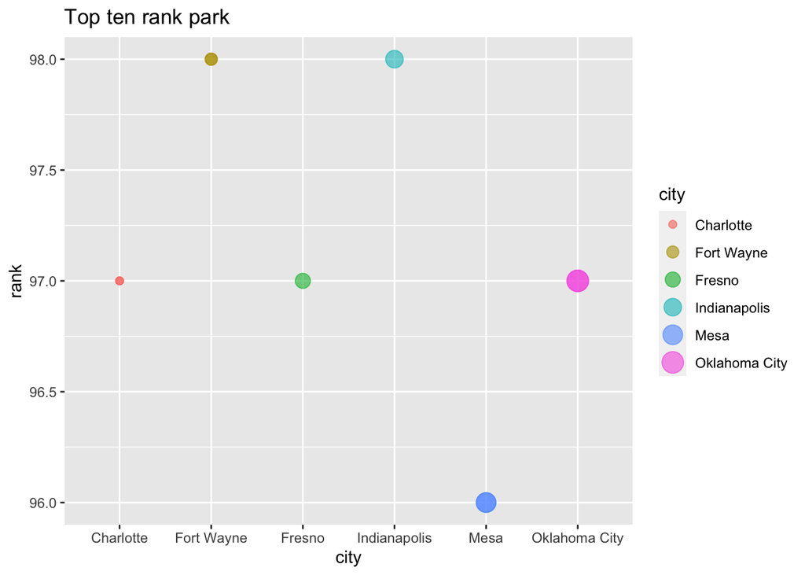

```r
ggplot(data)+
  geom_point(aes(x=city, y=rank,
                 color=city,
                 size=city), alpha=.6)+
  labs(title="Top ten rank park")
```

### Select cities which 75% of residents can walk to the park in ten minutes

```r
parks_dat = parks_df %>%
filter(pct_near_park_data > 75)%>%
select(year,city,pct_near_park_data)
parks_dat
```

```
## # A tibble: 266 × 3
##     year city                pct_near_park_data
##    <dbl> <fct>                            <dbl>
##  1  2020 Minneapolis                         98
##  2  2020 Washington, D.C.                    98
##  3  2020 St. Paul                            99
##  4  2020 Arlington, Virginia                 99
##  5  2020 Cincinnati                          82
##  6  2020 Portland                            90
##  7  2020 Irvine                              82
##  8  2020 San Francisco                      100
##  9  2020 Boston                             100
## 10  2020 Chicago                             98
## # … with 256 more rows
```

```r
parks_dat %>% group_by(city) %>% count(,sort = TRUE)
```

```
## # A tibble: 39 × 2
## # Groups:   city [39]
##    city             n
##    <fct>        <int>
##  1 Albuquerque      9
##  2 Baltimore        9
##  3 Boston           9
##  4 Chicago          9
##  5 Denver           9
##  6 Detroit          9
##  7 Milwaukee        9
##  8 New York         9
##  9 Philadelphia     9
## 10 Portland         9
## # … with 29 more rows
```

```
## No summary function supplied, defaulting to `mean_se()`
```

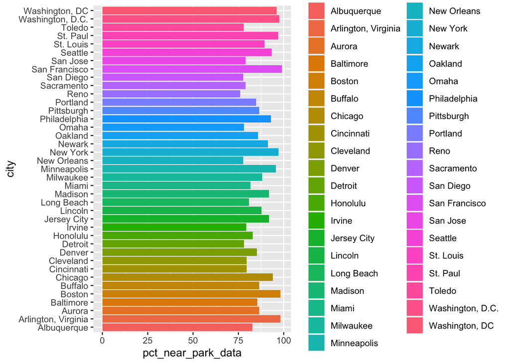

```r
parks_dat %>%
 ggplot()+ #visualization
  coord_flip()+   # this makes the plot horizontal
  geom_bar(
    aes(x=city,y=pct_near_park_data,fill=city),stat = "summary")
```

#### By analyzing the data we collected, we found that in 2020, when Covid-19 broke out, the government’s investment in parks increased slightly compared with the past, but the increase was insignificant. Some cities’ investments even declined might be affected by the economic downturn during the pandemic. While some cities, such as Arlington, Virginia, Minneapolis, Plano, Seattle, etc., increased their investment dramatically.

### Top ten Cities with highest total point

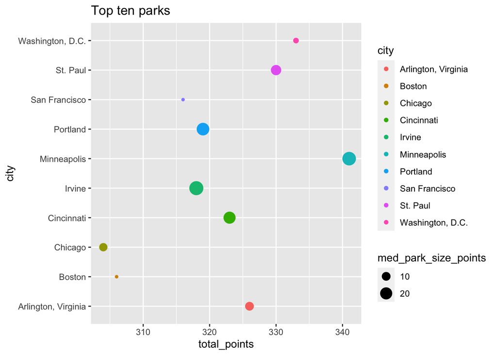

```r
parks_top10<-parks_df %>%
  arrange(desc(total_points),sort=TRUE) %>%
  head(10)
parks_top10 %>%
  ggplot(
  aes(total_points,city,colour=city,size=med_park_size_points,labs(title="Top ten rank park"))
  )+
  geom_count()+
  ggtitle("Top ten parks")
```

#### For these top 10 cities, their total points are all more than 300.

### Use lm() function to build model that predict total point based on data in data set. Using Parkland as % of city area points, Percent of residents within a 10 minute walk to park points,Spending per resident in points and Playgrounds per 10,000 residents points as variables and compare the results.

```r
park_lm<-parks_df %>%
  filter(!is.na(total_points))
lm_parks<-lm(total_points~park_pct_city_points, data=parks)
summary(lm_parks)
```

```
##
## Call:
## lm(formula = total_points ~ park_pct_city_points, data = parks)
##
## Residuals:
##      Min       1Q   Median       3Q      Max
## -110.725  -30.731   -0.837   16.808  169.113
##
## Coefficients:
##                      Estimate Std. Error t value Pr(>|t|)
## (Intercept)           19.8200     3.3732   5.876 7.27e-09 ***
## park_pct_city_points   4.8953     0.2055  23.820  < 2e-16 ***
## ---
## Signif. codes:  0 '***' 0.001 '**' 0.01 '*' 0.05 '.' 0.1 ' ' 1
##
## Residual standard error: 48.74 on 554 degrees of freedom
##   (157 observations deleted due to missingness)
## Multiple R-squared:  0.506,  Adjusted R-squared:  0.5051
## F-statistic: 567.4 on 1 and 554 DF,  p-value: < 2.2e-16
```

```r
lm_parks1<-lm(total_points~pct_near_park_points, data=parks)
summary(lm_parks1)
```

```
##
## Call:
## lm(formula = total_points ~ pct_near_park_points, data = parks)
##
## Residuals:
##      Min       1Q   Median       3Q      Max
## -103.894  -26.505   -0.641   21.158  181.686
##
## Coefficients:
##                      Estimate Std. Error t value Pr(>|t|)
## (Intercept)           4.75900    3.30812   1.439    0.151
## pct_near_park_points  2.72837    0.09493  28.740   <2e-16 ***
## ---
## Signif. codes:  0 '***' 0.001 '**' 0.01 '*' 0.05 '.' 0.1 ' ' 1
##
## Residual standard error: 43.94 on 554 degrees of freedom
##   (157 observations deleted due to missingness)
## Multiple R-squared:  0.5986, Adjusted R-squared:  0.5978
## F-statistic:   826 on 1 and 554 DF,  p-value: < 2.2e-16
```

```r
lm_parks2<-lm(total_points~spend_per_resident_points, data=parks)
summary(lm_parks2)
```

```
##
## Call:
## lm(formula = total_points ~ spend_per_resident_points, data = parks)
##
## Residuals:
##     Min      1Q  Median      3Q     Max
## -74.798 -12.249   0.839  12.360 141.476
##
## Coefficients:
##                           Estimate Std. Error t value Pr(>|t|)
## (Intercept)               26.41168    1.68193   15.70   <2e-16 ***
## spend_per_resident_points  2.91932    0.05798   50.35   <2e-16 ***
## ---
## Signif. codes:  0 '***' 0.001 '**' 0.01 '*' 0.05 '.' 0.1 ' ' 1
##
## Residual standard error: 29.37 on 554 degrees of freedom
##   (157 observations deleted due to missingness)
## Multiple R-squared:  0.8206, Adjusted R-squared:  0.8203
## F-statistic:  2535 on 1 and 554 DF,  p-value: < 2.2e-16
```

```r
lm_parks3<-lm(total_points~playground_points, data=parks)
summary(lm_parks3)
```

```
##
## Call:
## lm(formula = total_points ~ playground_points, data = parks)
##
## Residuals:
##      Min       1Q   Median       3Q      Max
## -138.564  -26.341   -5.247   15.402  236.020
##
## Coefficients:
##                   Estimate Std. Error t value Pr(>|t|)
## (Intercept)        32.7610     2.7175   12.06   <2e-16 ***
## playground_points   3.0580     0.1147   26.66   <2e-16 ***
## ---
## Signif. codes:  0 '***' 0.001 '**' 0.01 '*' 0.05 '.' 0.1 ' ' 1
##
## Residual standard error: 45.9 on 554 degrees of freedom
##   (157 observations deleted due to missingness)
## Multiple R-squared:  0.562,  Adjusted R-squared:  0.5612
## F-statistic: 710.8 on 1 and 554 DF,  p-value: < 2.2e-16
```

#### The most important factor is spending per resident in USD which means the more residents spend on the park, the higher are the total points. Other factors include park access, which means the percent of residents within a 10-minute walk to the park, playgrounds per 10,000 residents, parkland as a percentage of the city area, amenities, and so on.

### Comparing the top5 cities and the lowest five cities with total point in different ways.

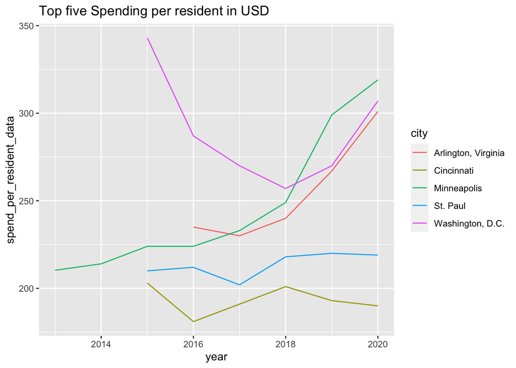

```r
parks_df %>%
  filter(city=="Minneapolis" |
           city=="Washington, D.C." |
           city=="St. Paul"|
           city=="Arlington, Virginia"|
           city=="Cincinnati") %>% ggplot(
  aes(year,spend_per_resident_data,colour=city,fill=city)
  )+
  geom_line()+
  ggtitle("Top five Spending per resident in USD")
```

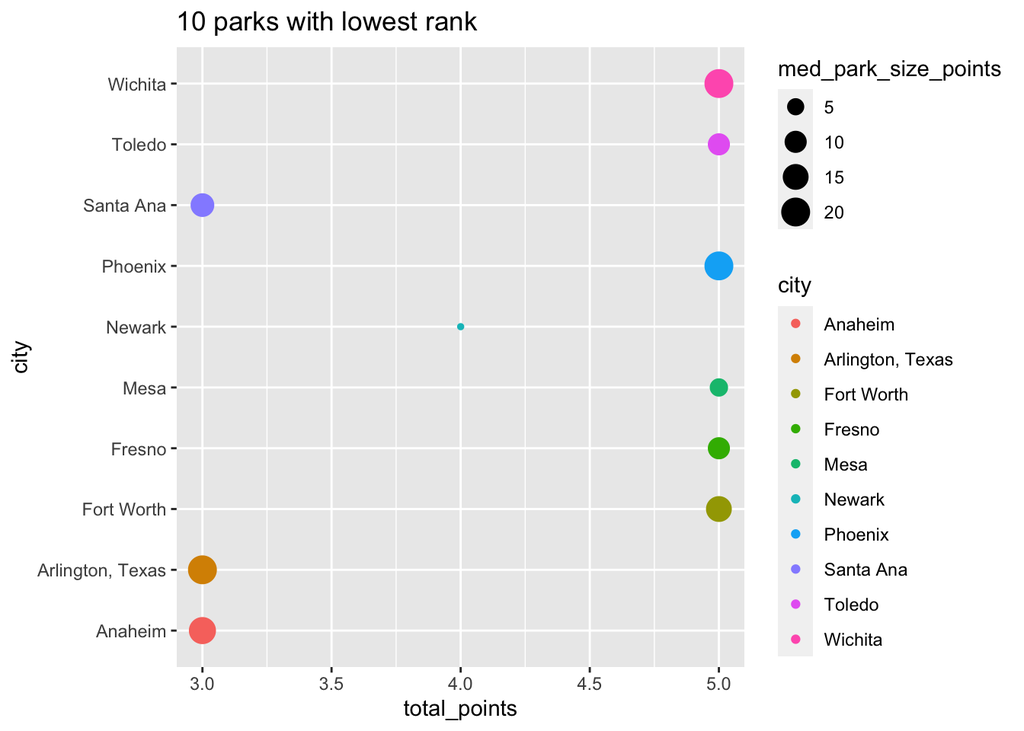

```r
parks_lowest10<-parks_df %>%
  arrange(total_points,sort=TRUE) %>%
  head(10)
parks_lowest10 %>%
  ggplot(
  aes(total_points,city,colour=city,size=med_park_size_points)
  )+
  geom_count()+
  ggtitle("10 parks with lowest rank")
```

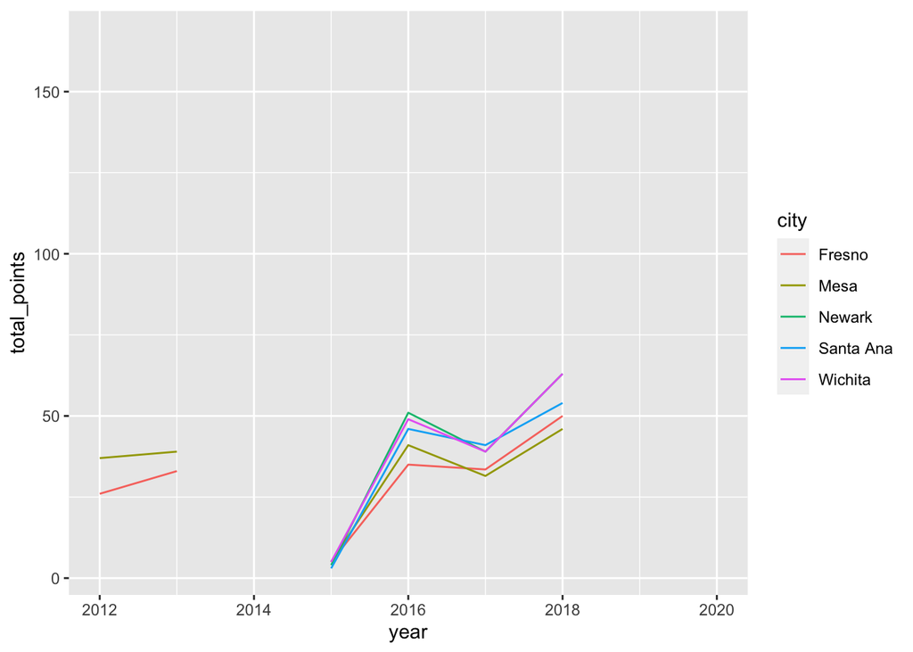

```r
parks_df %>%
  filter(city=="Fresno" |
           city=="Mesa" |
           city=="Santa Ana"|
           city=="Wichita"|
           city=="Newark") %>% ggplot(
  aes(year,total_points,colour=city,fill=city)
  )+
  geom_line()
```

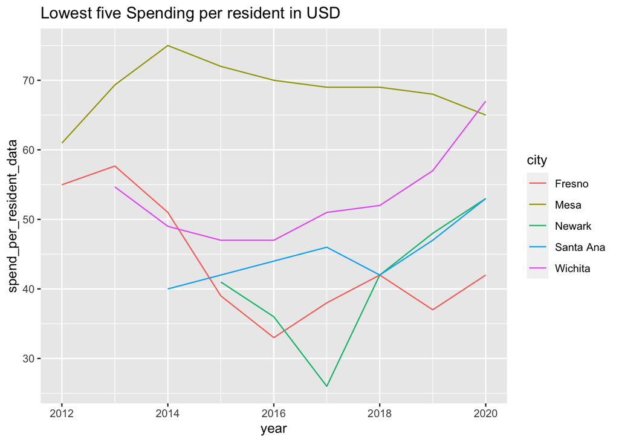

```r
parks_df %>%
  filter(city=="Fresno" |
           city=="Mesa" |
           city=="Santa Ana"|
           city=="Wichita"|
           city=="Newark") %>% ggplot(
  aes(year,spend_per_resident_data,colour=city,fill=city)
  )+
  geom_line()+
   ggtitle("Lowest five Spending per resident in USD")
```

#### Comparing the cities with the highest and lowest total point, the top cities have more parkland areas, are more convenient to access, and has more investment, especially after 2018.

### Camparision of parkland as percentage of city area and spending per resident in USD

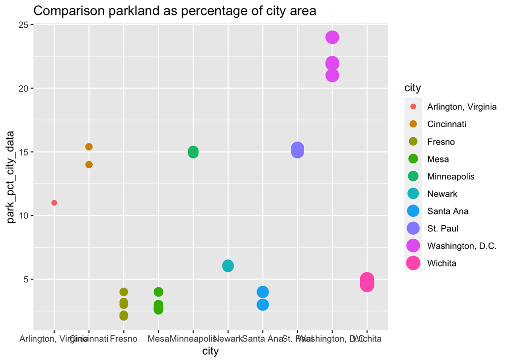

```r
parks_df %>%
  filter(city=="Fresno" |
           city=="Mesa" |
           city=="Santa Ana"|
           city=="Wichita"|
           city=="Newark" |
           city=="Minneapolis" |
           city=="Washington, D.C." |
           city=="St. Paul"|
           city=="Arlington, Virginia"|
           city=="Cincinnati"
           ) %>% ggplot(
 aes(city,park_pct_city_data,colour=city,size=city)
  )+
  geom_count()+
  ggtitle("Comparison parkland as percentage of city area")
```

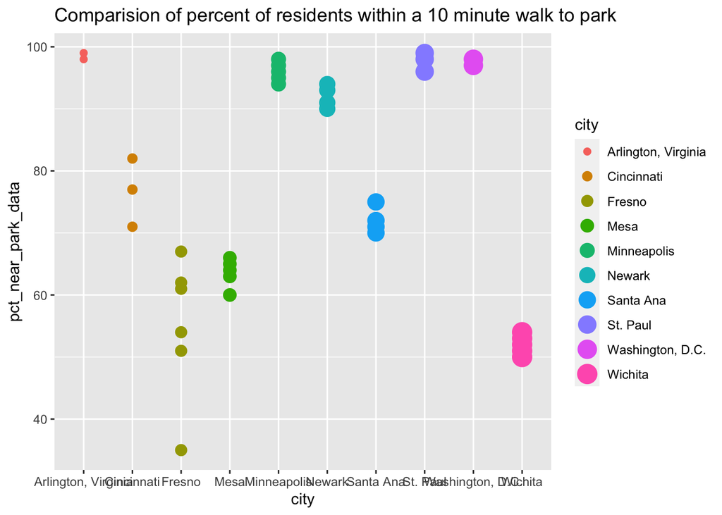

```r
parks_df %>%
  filter(city=="Fresno" |
           city=="Mesa" |
           city=="Santa Ana"|
           city=="Wichita"|
           city=="Newark" |
           city=="Minneapolis" |
           city=="Washington, D.C." |
           city=="St. Paul"|
           city=="Arlington, Virginia"|
           city=="Cincinnati"
           ) %>% ggplot(
 aes(city,pct_near_park_data,colour=city,size=city)
  )+
  geom_count()+
  ggtitle("Comparision of percent of residents within a 10 minute walk to park")
```

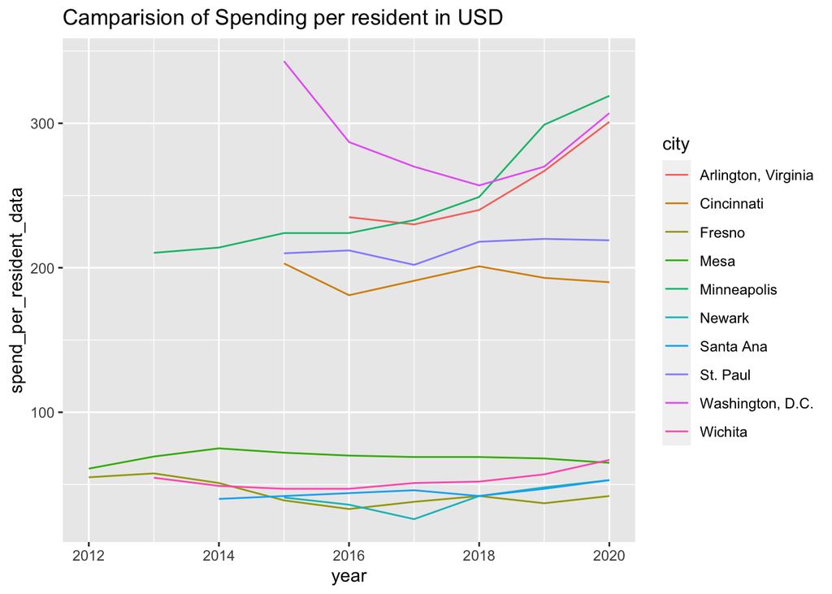

```r
parks_df %>%
  filter(city=="Fresno" |
           city=="Mesa" |
           city=="Santa Ana"|
           city=="Wichita"|
           city=="Newark" |
           city=="Minneapolis" |
           city=="Washington, D.C." |
           city=="St. Paul"|
           city=="Arlington, Virginia"|
           city=="Cincinnati"
         ) %>% ggplot(
  aes(year,spend_per_resident_data,colour=city,fill=city)
  )+
  geom_line()+
  ggtitle("Camparision of Spending per resident in USD")
```

#### cities with low total point scores have an insufficient investment in the early stage of parks and didn’t increase their investment significantly in recent years. The top green cities have good park access, more acreage, investment, and amenities. On the other hand, they increased investment significantly in green space or maintained a relatively high investment, resulting in a widening gap between the cities, highlighting the urgent need to centre equity in park investment and planning.

#### through analysis of the data, we found that in 2020, when Covid-19 broke out, the government’s investment in parks increased slightly compared with the past, but the increase was insignificant. Further observations are required to develop a conclusion.